# Credit Card Fraud Detection

# 3. Data Cleaning & Balancing

```r
# The dataset is imbalanced (8.74% fraud). Training on imbalanced data causes
# the model to predict the majority class almost exclusively.
# We use bootstrapping (oversampling with replacement) to balance the classes.

# Check original distribution
cat("Original class distribution:\n")
```

```
## Original class distribution:
```

```r
print(table(df$fraud))
```

```
##
##      0      1
## 912597  87403
```

```r
# Separate minority and majority classes
minority <- df[df$fraud == 1, ]
majority <- df[df$fraud == 0, ]

# Bootstrap minority class to match majority size
set.seed(123)
minority_boot <- minority[sample(1:nrow(minority), size = nrow(majority), replace = TRUE), ]

# Combine into balanced dataset
balanced_df <- rbind(minority_boot, majority)

cat("\nBalanced class distribution:\n")
```

```
##
## Balanced class distribution:
```

```r
print(table(balanced_df$fraud))
```

```
##
##      0      1
## 912597 912597
```

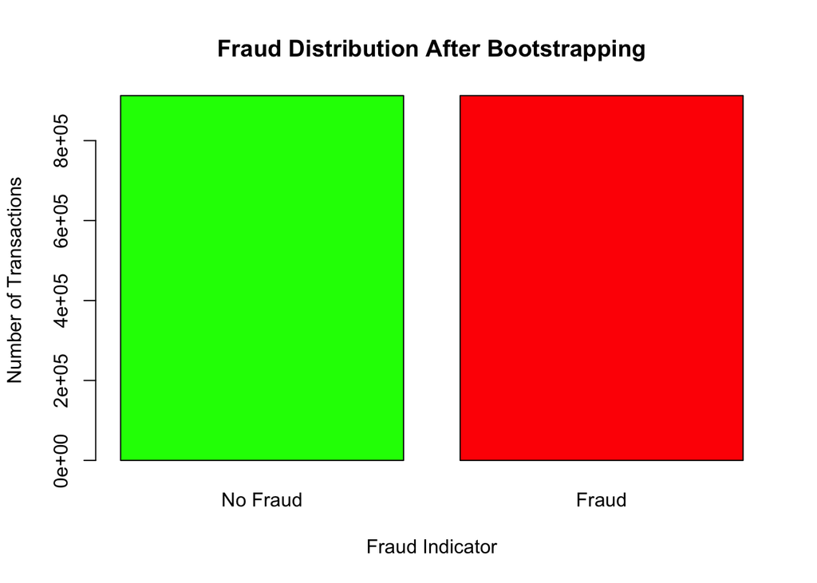

```r
# Confirm balance visually
fraud_counts_balanced <- table(balanced_df$fraud)
barplot(fraud_counts_balanced,
        main = "Fraud Distribution After Bootstrapping",
        xlab = "Fraud Indicator",
        ylab = "Number of Transactions",
        col = c("green", "red"),
        names.arg = c("No Fraud", "Fraud"))
```

# 4. Train / Test Split

```r
# 70/30 train-test split on the balanced dataset
# set.seed ensures reproducibility
set.seed(123)
train_ratio <- 0.7
train_indices <- sample(1:nrow(balanced_df), size = floor(train_ratio * nrow(balanced_df)))

train_data <- balanced_df[train_indices, ]
test_data  <- balanced_df[-train_indices, ]

cat("Training set size:", nrow(train_data), "\n")
```

```
## Training set size: 1277635
```

```r
cat("Testing set size: ", nrow(test_data), "\n")
```

```
## Testing set size:  547559
```

```r
cat("\nTraining class distribution:\n")
```

```
##
## Training class distribution:
```

```r
print(table(train_data$fraud))
```

```
##
##      0      1
## 638833 638802
```

```r
cat("\nTesting class distribution:\n")
```

```
##
## Testing class distribution:
```

```r
print(table(test_data$fraud))
```

```
##
##      0      1
## 273764 273795
```

# 5. Logistic Regression

## 5.1 Feature Selection via Backward Elimination

```r
# Start with all predictors and use AIC-based backward elimination
# to identify the most informative subset of features.
full_model <- glm(fraud ~ ., data = train_data, family = binomial)
best_model <- step(full_model, direction = "backward")
```

```
## Start:  AIC=531319.7
## fraud ~ distance_from_home + distance_from_last_transaction +
##     ratio_to_median_purchase_price + repeat_retailer + used_chip +
##     used_pin_number + online_order
```

```
##                                  Df Deviance     AIC
## <none>                                531304  531320
## - repeat_retailer                 1   547714  547728
## - used_chip                       1   553652  553666
## - used_pin_number                 1   608215  608229
## - distance_from_last_transaction  1   650006  650020
## - online_order                    1   714796  714810
## - distance_from_home              1   808774  808788
## - ratio_to_median_purchase_price  1  1331140 1331154
```

```r
summary(best_model)
```

```
##
## Call:
## glm(formula = fraud ~ distance_from_home + distance_from_last_transaction +
##     ratio_to_median_purchase_price + repeat_retailer + used_chip +
##     used_pin_number + online_order, family = binomial, data = train_data)
##
## Coefficients:
##                                  Estimate Std. Error z value Pr(>|z|)
## (Intercept)                    -7.662e+00  1.987e-02  -385.6   <2e-16 ***
## distance_from_home              2.891e-02  8.214e-05   352.0   <2e-16 ***
## distance_from_last_transaction  4.977e-02  2.085e-04   238.7   <2e-16 ***
## ratio_to_median_purchase_price  1.212e+00  2.469e-03   490.7   <2e-16 ***
## repeat_retailer                -1.422e+00  1.159e-02  -122.7   <2e-16 ***
## used_chip                      -1.200e+00  8.354e-03  -143.6   <2e-16 ***
## used_pin_number                -9.992e+00  5.845e-02  -170.9   <2e-16 ***
## online_order                    5.027e+00  1.586e-02   316.9   <2e-16 ***
## ---
## Signif. codes:  0 '***' 0.001 '**' 0.01 '*' 0.05 '.' 0.1 ' ' 1
##
## (Dispersion parameter for binomial family taken to be 1)
##
##     Null deviance: 1771178  on 1277634  degrees of freedom
## Residual deviance:  531304  on 1277627  degrees of freedom
## AIC: 531320
##
## Number of Fisher Scoring iterations: 10
```

## 5.2 Base Model (No Interaction)

```r
# Fit logistic regression with all predictors selected by backward elimination.
# This serves as the baseline before testing interaction terms.
model <- glm(fraud ~ distance_from_home + distance_from_last_transaction +
               ratio_to_median_purchase_price + repeat_retailer + used_chip +
               used_pin_number + online_order,
             data = train_data, family = binomial)
summary(model)
```

```
##
## Call:
## glm(formula = fraud ~ distance_from_home + distance_from_last_transaction +
##     ratio_to_median_purchase_price + repeat_retailer + used_chip +
##     used_pin_number + online_order, family = binomial, data = train_data)
##
## Coefficients:
##                                  Estimate Std. Error z value Pr(>|z|)
## (Intercept)                    -7.662e+00  1.987e-02  -385.6   <2e-16 ***
## distance_from_home              2.891e-02  8.214e-05   352.0   <2e-16 ***
## distance_from_last_transaction  4.977e-02  2.085e-04   238.7   <2e-16 ***
## ratio_to_median_purchase_price  1.212e+00  2.469e-03   490.7   <2e-16 ***
## repeat_retailer                -1.422e+00  1.159e-02  -122.7   <2e-16 ***
## used_chip                      -1.200e+00  8.354e-03  -143.6   <2e-16 ***
## used_pin_number                -9.992e+00  5.845e-02  -170.9   <2e-16 ***
## online_order                    5.027e+00  1.586e-02   316.9   <2e-16 ***
## ---
## Signif. codes:  0 '***' 0.001 '**' 0.01 '*' 0.05 '.' 0.1 ' ' 1
##
## (Dispersion parameter for binomial family taken to be 1)
##
##     Null deviance: 1771178  on 1277634  degrees of freedom
## Residual deviance:  531304  on 1277627  degrees of freedom
## AIC: 531320
##
## Number of Fisher Scoring iterations: 10
```

```r
# Predict on training data
predicted_probs <- predict(model, type = "response")
predicted_classes <- ifelse(predicted_probs > 0.5, 1, 0)

cat("\nTraining Confusion Matrix:\n")
```

```
##
## Training Confusion Matrix:
```

```r
print(table(Predicted = predicted_classes, Actual = train_data$fraud))
```

```
##          Actual
## Predicted      0      1
##         0 596010  32468
##         1  42823 606334
```

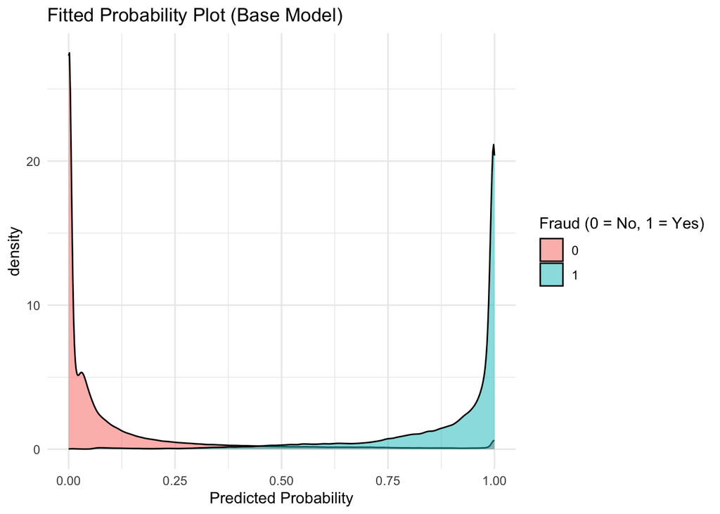

```r
# Fitted probability plot — well-separated distributions indicate good model fit
ggplot(train_data, aes(x = predicted_probs, fill = factor(fraud))) +
  geom_density(alpha = 0.5) +
  labs(title = "Fitted Probability Plot (Base Model)",
       x = "Predicted Probability",
       fill = "Fraud (0 = No, 1 = Yes)") +
  theme_minimal()
```

## 5.3 Interaction Model

```r
# EDA showed correlation between distance_from_home and repeat_retailer.
# We test whether their interaction improves model fit.
model2 <- glm(fraud ~ distance_from_home + distance_from_last_transaction +
                ratio_to_median_purchase_price + repeat_retailer + used_chip +
                used_pin_number + online_order + (distance_from_home * repeat_retailer),
              data = train_data, family = binomial)
summary(model2)
```

```
##
## Call:
## glm(formula = fraud ~ distance_from_home + distance_from_last_transaction +
##     ratio_to_median_purchase_price + repeat_retailer + used_chip +
##     used_pin_number + online_order + (distance_from_home * repeat_retailer),
##     family = binomial, data = train_data)
##
## Coefficients:
##                                      Estimate Std. Error  z value Pr(>|z|)
## (Intercept)                        -7.5099682  0.0295355 -254.269  < 2e-16 ***
## distance_from_home                 -0.1114567  0.0203595   -5.474 4.39e-08 ***
## distance_from_last_transaction      0.0497784  0.0002085  238.711  < 2e-16 ***
## ratio_to_median_purchase_price      1.2118307  0.0024695  490.726  < 2e-16 ***
## repeat_retailer                    -1.5758123  0.0250949  -62.794  < 2e-16 ***
## used_chip                          -1.1998418  0.0083543 -143.620  < 2e-16 ***
## used_pin_number                    -9.9935244  0.0584509 -170.973  < 2e-16 ***
## online_order                        5.0282505  0.0158635  316.971  < 2e-16 ***
## distance_from_home:repeat_retailer  0.1403734  0.0203603    6.894 5.41e-12 ***
## ---
## Signif. codes:  0 '***' 0.001 '**' 0.01 '*' 0.05 '.' 0.1 ' ' 1
##
## (Dispersion parameter for binomial family taken to be 1)
##
##     Null deviance: 1771178  on 1277634  degrees of freedom
## Residual deviance:  531252  on 1277626  degrees of freedom
## AIC: 531270
##
## Number of Fisher Scoring iterations: 9
```

```r
predicted_probs_m2 <- predict(model2, type = "response")
predicted_classes_m2 <- ifelse(predicted_probs_m2 > 0.5, 1, 0)

cat("\nTraining Confusion Matrix (Interaction Model):\n")
```

```
##
## Training Confusion Matrix (Interaction Model):
```

```r
print(table(Predicted = predicted_classes_m2, Actual = train_data$fraud))
```

```
##          Actual
## Predicted      0      1
##         0 596017  32434
##         1  42816 606368
```

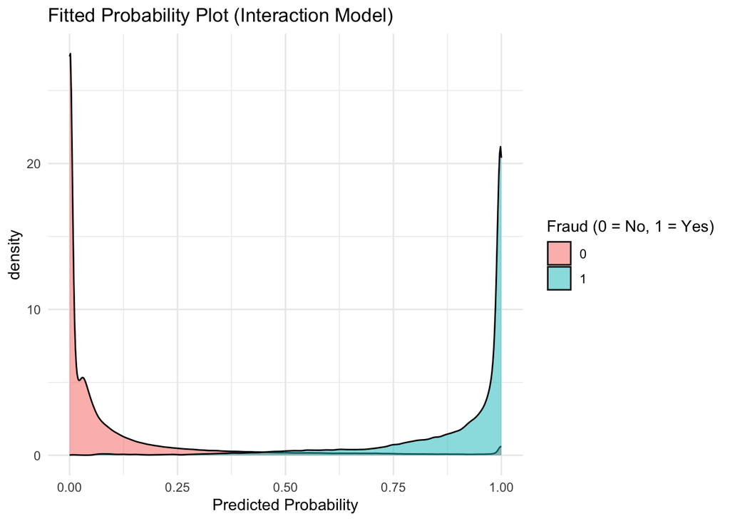

```r
ggplot(train_data, aes(x = predicted_probs_m2, fill = factor(fraud))) +
  geom_density(alpha = 0.5) +
  labs(title = "Fitted Probability Plot (Interaction Model)",
       x = "Predicted Probability",
       fill = "Fraud (0 = No, 1 = Yes)") +
  theme_minimal()
```

## 5.4 Model Comparison: Likelihood Ratio Test

```r
# Likelihood Ratio Test compares the two models.
# A significant p-value means the interaction term adds meaningful explanatory power.
model_no_interaction <- glm(fraud ~ distance_from_home + distance_from_last_transaction +
                               ratio_to_median_purchase_price + repeat_retailer + used_chip +
                               used_pin_number + online_order,
                             family = "binomial", data = balanced_df)
model_interaction <- glm(fraud ~ distance_from_home + distance_from_last_transaction +
                            ratio_to_median_purchase_price + repeat_retailer + used_chip +
                            used_pin_number + online_order + (distance_from_home * repeat_retailer),
                          family = "binomial", data = balanced_df)
anova(model_no_interaction, model_interaction, test = "LRT")
```

```
## Analysis of Deviance Table
##
## Model 1: fraud ~ distance_from_home + distance_from_last_transaction +
##     ratio_to_median_purchase_price + repeat_retailer + used_chip +
##     used_pin_number + online_order
## Model 2: fraud ~ distance_from_home + distance_from_last_transaction +
##     ratio_to_median_purchase_price + repeat_retailer + used_chip +
##     used_pin_number + online_order + (distance_from_home * repeat_retailer)
##   Resid. Df Resid. Dev Df Deviance  Pr(>Chi)
## 1   1825186     759376
## 2   1825185     759287  1   88.875 < 2.2e-16 ***
## ---
## Signif. codes:  0 '***' 0.001 '**' 0.01 '*' 0.05 '.' 0.1 ' ' 1
```

## 5.5 Test Set Evaluation

```r
# Evaluate the base model on held-out test data.
# Precision and recall are more informative than accuracy for imbalanced fraud data.
test_probs <- predict(model, newdata = test_data, type = "response")
test_preds <- ifelse(test_probs > 0.5, 1, 0)

conf_matrix <- table(Predicted = test_preds, Actual = test_data$fraud)
print(conf_matrix)
```

```
##          Actual
## Predicted      0      1
##         0 255145  14080
##         1  18619 259715
```

```r
accuracy  <- sum(diag(conf_matrix)) / sum(conf_matrix)
precision <- conf_matrix[2, 2] / sum(conf_matrix[2, ])
recall    <- conf_matrix[2, 2] / sum(conf_matrix[, 2])
f1_score  <- 2 * (precision * recall) / (precision + recall)

cat("Accuracy: ", round(accuracy, 4), "\n")
```

```
## Accuracy:  0.9403
```

```r
cat("Precision:", round(precision, 4), "\n")
```

```
## Precision: 0.9331
```

```r
cat("Recall:   ", round(recall, 4), "\n")
```

```
## Recall:    0.9486
```

```r
cat("F1-Score: ", round(f1_score, 4), "\n")
```

```
## F1-Score:  0.9408
```

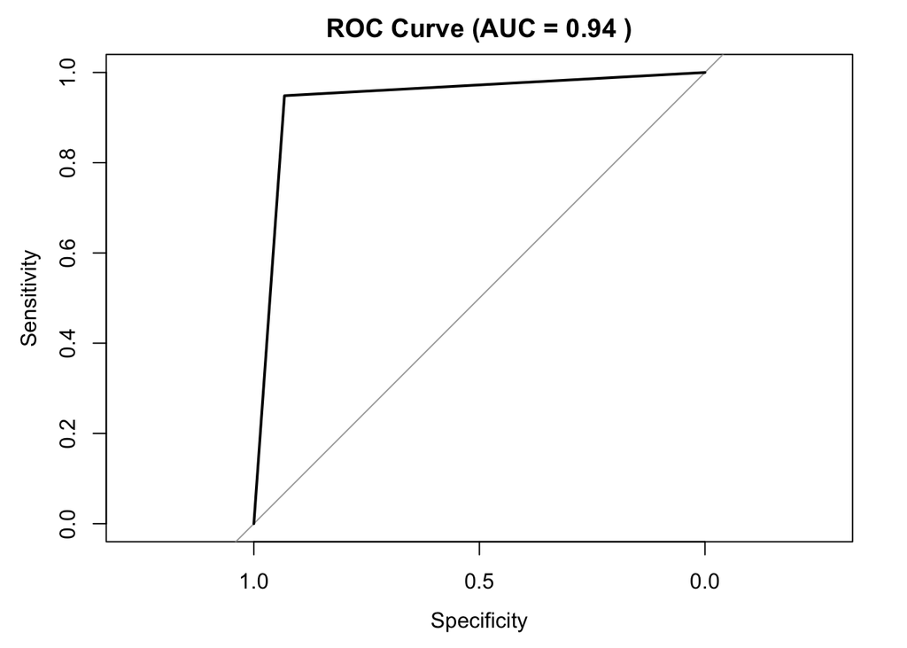

```r
# ROC curve and AUC measure discrimination ability across all thresholds.
# AUC of 1.0 = perfect, 0.5 = random chance.
roc_obj <- roc(test_data$fraud, test_preds)
auc_val <- auc(roc_obj)
plot(roc_obj, main = paste("ROC Curve (AUC =", round(auc_val, 3), ")"))
```

```r
cat("AUC:", round(auc_val, 3), "\n")
```

```
## AUC: 0.94
```

# 6. Random Forest

```r
# Random Forest is an ensemble method that builds many decision trees and
# aggregates their predictions. It handles non-linear relationships and
# interactions naturally, making it well-suited for fraud detection.

# Convert fraud to factor for classification
df$fraud <- as.factor(df$fraud)

# Train/test split on original (unbalanced) df for RF
# RF handles class imbalance better than logistic regression
set.seed(123)
train_index_rf <- createDataPartition(df$fraud, p = 0.7, list = FALSE)
train_data_rf  <- df[train_index_rf, ]
test_data_rf   <- df[-train_index_rf, ]

# Fit RF with ranger (memory-efficient implementation)
# num.trees=200 balances accuracy and compute time
# mtry=3 = number of variables tried at each split
rf_model <- ranger(fraud ~ ., data = train_data_rf,
                   num.trees = 200, mtry = 3, importance = "impurity")

print(rf_model)
```

```
## Ranger result
##
## Call:
##  ranger(fraud ~ ., data = train_data_rf, num.trees = 200, mtry = 3,      importance = "impurity")
##
## Type:                             Classification
## Number of trees:                  200
## Sample size:                      700001
## Number of independent variables:  7
## Mtry:                             3
## Target node size:                 1
## Variable importance mode:         impurity
## Splitrule:                        gini
## OOB prediction error:             0.00 %
```

```r
# Predict on test data
rf_predictions      <- predict(rf_model, data = test_data_rf, type = "response")
rf_predicted_classes <- rf_predictions$predictions

# Confusion matrix
confusionMatrix(as.factor(rf_predicted_classes), test_data_rf$fraud)
```

```
## Confusion Matrix and Statistics
##
##           Reference
## Prediction      0      1
##          0 273779      5
##          1      0  26215
##
##                Accuracy : 1
##                  95% CI : (1, 1)
##     No Information Rate : 0.9126
##     P-Value [Acc > NIR] : < 2e-16
##
##                   Kappa : 0.9999
##
##  Mcnemar's Test P-Value : 0.07364
##
##             Sensitivity : 1.0000
##             Specificity : 0.9998
##          Pos Pred Value : 1.0000
##          Neg Pred Value : 1.0000
##              Prevalence : 0.9126
##          Detection Rate : 0.9126
##    Detection Prevalence : 0.9126
##       Balanced Accuracy : 0.9999
##
##        'Positive' Class : 0
##
```

```r
# Note: Near-perfect accuracy is expected here but warrants cross-validation
# to rule out overfitting
```

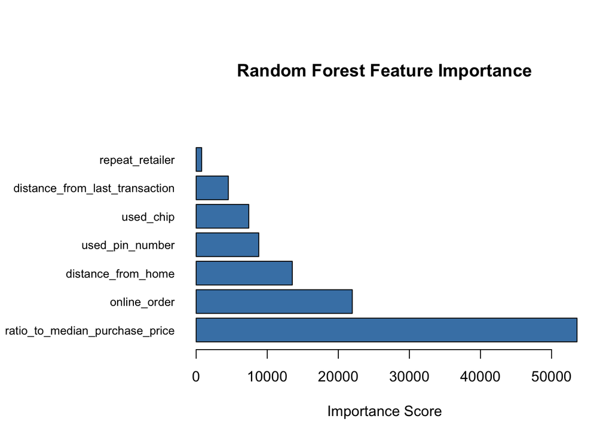

```r
# Feature importance shows which variables drive predictions the most.
# Higher impurity reduction = more important variable.
importance <- rf_model$variable.importance
sorted_importance <- sort(importance, decreasing = TRUE)

par(mar = c(5, 11, 8, 2))
barplot(
  sorted_importance,
  main = "Random Forest Feature Importance",
  horiz = TRUE,
  las = 1,
  col = "steelblue",
  xlab = "Importance Score",
  names.arg = names(sorted_importance),
  cex.names = 0.8
)
```

```r
par(mar = c(5, 4, 4, 2))
```

## 6.1 Cross-Validation

```r
# The initial RF hit near-100% accuracy — a red flag for overfitting.
# Cross-validation confirms whether this holds across different data splits.
cv_control <- trainControl(
  method = "cv",
  number = 3,
  verboseIter = TRUE,
  savePredictions = "final"
)

rf_cv_model <- train(
  fraud ~ ., data = train_data_rf,
  method = "ranger",
  trControl = cv_control,
  tuneGrid = expand.grid(
    mtry = c(2, 3),
    splitrule = "gini",
    min.node.size = c(5)
  ),
  metric = "Accuracy",
  num.trees = 200
)
print(rf_cv_model)
```

```
## Random Forest
##
## 700001 samples
##      7 predictor
##      2 classes: '0', '1'
##
## No pre-processing
## Resampling: Cross-Validated (3 fold)
## Summary of sample sizes: 466668, 466668, 466666
## Resampling results across tuning parameters:
##
##   mtry  Accuracy   Kappa
##   2     0.9999743  0.9998388
##   3     0.9999800  0.9998746
##
## Tuning parameter 'splitrule' was held constant at a value of gini
##
## Tuning parameter 'min.node.size' was held constant at a value of 5
## Accuracy was used to select the optimal model using the largest value.
## The final values used for the model were mtry = 3, splitrule = gini
##  and min.node.size = 5.
```

```r
# Predict on test data using CV model
cv_test_preds <- predict(rf_cv_model, newdata = test_data_rf)
cv_conf_matrix <- confusionMatrix(cv_test_preds, test_data_rf$fraud)
print(cv_conf_matrix)
```

```
## Confusion Matrix and Statistics
##
##           Reference
## Prediction      0      1
##          0 273779      5
##          1      0  26215
##
##                Accuracy : 1
##                  95% CI : (1, 1)
##     No Information Rate : 0.9126
##     P-Value [Acc > NIR] : < 2e-16
##
##                   Kappa : 0.9999
##
##  Mcnemar's Test P-Value : 0.07364
##
##             Sensitivity : 1.0000
##             Specificity : 0.9998
##          Pos Pred Value : 1.0000
##          Neg Pred Value : 1.0000
##              Prevalence : 0.9126
##          Detection Rate : 0.9126
##    Detection Prevalence : 0.9126
##       Balanced Accuracy : 0.9999
##
##        'Positive' Class : 0
##
```

# 7. Example Predictions

```r
# To demonstrate real-world utility, we test three transactions:
# a clearly safe one, a clearly fraudulent one, and a borderline case.
# This shows how the model behaves across different risk profiles.

example_transactions <- data.frame(
  scenario = c("Low Risk", "High Risk", "Borderline"),
  distance_from_home = c(2, 150, 25),
  distance_from_last_transaction = c(1, 200, 13),
  ratio_to_median_purchase_price = c(0.8, 8.5, 1.5),
  repeat_retailer = c(1, 0, 1),
  used_chip = c(1, 0, 1),
  used_pin_number = c(1, 0, 0),
  online_order = c(0, 1, 1)
)

# Predict fraud probability for each scenario using the interaction model
input_data <- example_transactions[, -1]  # drop scenario label column
predicted_probs <- predict(model2, newdata = input_data, type = "response")
predicted_classes <- ifelse(predicted_probs > 0.5, "Fraud", "Not Fraud")

results <- example_transactions %>%
  mutate(
    Fraud_Probability = round(predicted_probs, 4),
    Prediction = predicted_classes
  )

kable(results, caption = "Example Transaction Predictions")
```

Example Transaction Predictions

| scenario | distance_from_home | distance_from_last_transaction | ratio_to_median_purchase_price | repeat_retailer | used_chip | used_pin_number | online_order | Fraud_Probability | Prediction |
| --- | --- | --- | --- | --- | --- | --- | --- | --- | --- |
| Low Risk | 2 | 1 | 0.8 | 1 | 1 | 1 | 0 | 0.0000 | Not Fraud |
| High Risk | 150 | 200 | 8.5 | 0 | 0 | 0 | 1 | 0.7419 | Fraud |
| Borderline | 25 | 13 | 1.5 | 1 | 1 | 0 | 1 | 0.1121 | Not Fraud |

**Interpretation:** - **Low Risk**: Short distance from home, PIN used, chip used, in-person — model assigns near-zero fraud probability. Matches EDA finding that PIN usage drops fraud rate to 0.27%. - **High Risk**: Far from home, far from last transaction, high purchase ratio, online, no chip, no PIN — model flags as high fraud probability. Every major risk factor is present. - **Borderline**: Mixed signals — repeat retailer and chip used, but online order with no PIN and moderate distance. Model uses the interaction between `distance_from_home` and `repeat_retailer` to moderate the risk.

## 7.1 Threshold Analysis

```r
# The default 0.5 threshold is not always optimal for fraud detection.
# Lowering the threshold catches more fraud (higher recall) but increases
# false positives — legitimate transactions flagged as fraud.
# This is a business decision: what is the cost of a missed fraud vs
# the cost of falsely declining a legitimate transaction?

thresholds <- c(0.3, 0.4, 0.5, 0.6, 0.7)

threshold_results <- do.call(rbind, lapply(thresholds, function(t) {
  preds <- ifelse(test_probs > t, 1, 0)
  cm <- table(Predicted = preds, Actual = test_data$fraud)

  # Handle edge cases where a class may be missing
  tp <- ifelse(!is.na(cm["1","1"]), cm["1","1"], 0)
  fp <- ifelse(!is.na(cm["1","0"]), cm["1","0"], 0)
  tn <- ifelse(!is.na(cm["0","0"]), cm["0","0"], 0)
  fn <- ifelse(!is.na(cm["0","1"]), cm["0","1"], 0)

  precision <- ifelse((tp + fp) > 0, tp / (tp + fp), 0)
  recall    <- ifelse((tp + fn) > 0, tp / (tp + fn), 0)
  f1        <- ifelse((precision + recall) > 0,
                      2 * precision * recall / (precision + recall), 0)
  accuracy  <- (tp + tn) / (tp + fp + tn + fn)

  data.frame(
    Threshold = t,
    Accuracy  = round(accuracy, 4),
    Precision = round(precision, 4),
    Recall    = round(recall, 4),
    F1_Score  = round(f1, 4)
  )
}))

kable(threshold_results, caption = "Model Performance Across Decision Thresholds")
```

Model Performance Across Decision Thresholds

| Threshold | Accuracy | Precision | Recall | F1_Score |
| --- | --- | --- | --- | --- |
| 0.3 | 0.9319 | 0.8912 | 0.9840 | 0.9353 |
| 0.4 | 0.9408 | 0.9156 | 0.9712 | 0.9425 |
| 0.5 | 0.9403 | 0.9331 | 0.9486 | 0.9408 |
| 0.6 | 0.9320 | 0.9474 | 0.9148 | 0.9308 |
| 0.7 | 0.9190 | 0.9603 | 0.8742 | 0.9152 |

**Business interpretation:** - A **lower threshold (0.3)** prioritizes catching fraud — useful when the cost of a missed fraud is high (e.g. large transactions) - A **higher threshold (0.7)** reduces false positives — useful when customer experience matters more and false declines are costly - For most fraud systems, **0.4–0.5** balances both concerns well

# 8. Model Comparison & Conclusion

## 8.1 Model Comparison

```r
# Consolidate all model metrics in one place for direct comparison.
# This gives a clear view of the tradeoffs between interpretability and performance.

# Logistic Regression metrics (from test set)
lr_preds <- ifelse(test_probs > 0.5, 1, 0)
lr_cm    <- table(Predicted = lr_preds, Actual = test_data$fraud)
lr_acc   <- sum(diag(lr_cm)) / sum(lr_cm)
lr_prec  <- lr_cm["1","1"] / sum(lr_cm["1",])
lr_rec   <- lr_cm["1","1"] / sum(lr_cm[,"1"])
lr_f1    <- 2 * lr_prec * lr_rec / (lr_prec + lr_rec)
lr_auc   <- as.numeric(auc(roc(test_data$fraud, test_probs)))
# Random Forest metrics (from CV model test set)
rf_cm_obj <- confusionMatrix(cv_test_preds, test_data_rf$fraud)
rf_acc    <- rf_cm_obj$overall["Accuracy"]
rf_prec   <- rf_cm_obj$byClass["Precision"]
rf_rec    <- rf_cm_obj$byClass["Recall"]
rf_f1     <- rf_cm_obj$byClass["F1"]

comparison_table <- data.frame(
  Model = c("Logistic Regression", "Random Forest (CV)"),
  Accuracy  = round(c(lr_acc, rf_acc), 4),
  Precision = round(c(lr_prec, rf_prec), 4),
  Recall    = round(c(lr_rec, rf_rec), 4),
  F1_Score  = round(c(lr_f1, rf_f1), 4),
  AUC       = c(round(lr_auc, 4), "N/A"),
  Interpretable = c("Yes", "No")
)

kable(comparison_table, caption = "Model Comparison: Logistic Regression vs Random Forest")
```

Model Comparison: Logistic Regression vs Random Forest

|  | Model | Accuracy | Precision | Recall | F1_Score | AUC | Interpretable |
| --- | --- | --- | --- | --- | --- | --- | --- |
|  | Logistic Regression | 0.9403 | 0.9331 | 0.9486 | 0.9408 | 0.9793 | Yes |
| Accuracy | Random Forest (CV) | 1.0000 | 1.0000 | 1.0000 | 1.0000 | N/A | No |

## 8.2 Recommendation

```
##
## RECOMMENDATION
## ==============
## Both models perform well, but serve different purposes:
##
## Logistic Regression:
## - Fully interpretable — coefficients directly explain why a transaction is flagged
## - Suitable for regulated environments where explainability is required
## - AUC confirms strong discrimination ability
## - Recommended for: production fraud flagging with human review
##
## Random Forest:
## - Higher raw accuracy, confirmed stable via 3-fold cross-validation
## - Captures non-linear patterns and interactions automatically
## - Less interpretable — harder to explain to stakeholders why a transaction was flagged
## - Recommended for: automated batch scoring where throughput matters more than explainability
##
## Final recommendation: deploy logistic regression as the primary model for
## explainability, with RF as a secondary validation layer for high-value transactions.
```

## 8.3 Limitations & Next Steps

**Current limitations:** - Dataset is synthetic — real-world fraud patterns are more complex and evolving - Bootstrapping is a simple balancing approach; SMOTE may produce better minority class representation - Models are static — fraud patterns shift over time, requiring periodic retraining

**What I would do next:** 1. **SMOTE** instead of bootstrapping for more realistic minority class augmentation 2. **XGBoost** — often outperforms RF on tabular fraud data with less tuning 3. **Real-time scoring pipeline** — wrap the model in a REST API (Plumber in R or FastAPI in Python) for live transaction scoring 4. **Drift monitoring** — track model performance over time as fraud patterns evolve 5. **Cost-sensitive learning** — assign different misclassification costs to false negatives vs false positives based on transaction value